# 25__zadanie_domowe__modul_4_1 (2)

## O Danych

Zbiór danych zawiera informacje o trzech gatunkach irysów: Iris setosa, Iris versicolor, i Iris virginica.

Dane obejmują pomiary czterech cech: długość i szerokość działki kielicha oraz długość i szerokość płatka.

Każdy wiersz w zbiorze danych reprezentuje pojedynczy kwiat, a wartości pomiarów są podane w centymetrach.

Zbiór składa się z 150 próbek, po 50 dla każdego gatunku, i jest szeroko stosowany jako podstawowy zbiór danych do testowania algorytmów klasyfikacji oraz w nauce o danych i uczeniu maszynowym.

Kolumny:

- **długość kielicha (sepal length)** - Długość kielicha w cm
- **szerokość kielicha (sepal width)** - Szerokość kielicha w cm
- **długość płatka (petal length)** - Długość płatka w cm
- **szerokość płatka (petal width)** - Szerokość płatka w cm
- **klasa (class)** - Klasa irysa (setosa, versicolor, virginica)

# Import pakietu panda oraz wczytanie pliku CSV z danymi do analizy.

```python
import pandas as pd
```

```python
df = pd.read_csv('25__iris.csv', sep=",")
df
```

|  | długość kielicha (sepal length) | szerokość kielicha (sepal width) | długość płatka (petal length) | szerokość płatka (petal width) | klasa (class) |
| --- | --- | --- | --- | --- | --- |
| 0 | 5.1 | 3.5 | 1.4 | 0.2 | Iris-setosa |
| 1 | 4.9 | 3.0 | 1.4 | 0.2 | Iris-setosa |
| 2 | 4.7 | 3.2 | 1.3 | 0.2 | Iris-setosa |
| 3 | 4.6 | 3.1 | 1.5 | 0.2 | Iris-setosa |
| 4 | 5.0 | 3.6 | 1.4 | 0.2 | Iris-setosa |
| ... | ... | ... | ... | ... | ... |
| 145 | 6.7 | 3.0 | 5.2 | 2.3 | Iris-virginica |
| 146 | 6.3 | 2.5 | 5.0 | 1.9 | Iris-virginica |
| 147 | 6.5 | 3.0 | 5.2 | 2.0 | Iris-virginica |
| 148 | 6.2 | 3.4 | 5.4 | 2.3 | Iris-virginica |
| 149 | 5.9 | 3.0 | 5.1 | 1.8 | Iris-virginica |

150 rows × 5 columns

# Ogólny przegląd danych.

```python
df.info() #ogólne informacje o wczytanych danych
```

```
<class 'pandas.core.frame.DataFrame'>
RangeIndex: 150 entries, 0 to 149
Data columns (total 5 columns):
 #   Column                            Non-Null Count  Dtype
---  ------                            --------------  -----
 0   długość kielicha (sepal length)   150 non-null    float64
 1   szerokość kielicha (sepal width)  150 non-null    float64
 2   długość płatka (petal length)     150 non-null    float64
 3   szerokość płatka (petal width)    150 non-null    float64
 4   klasa (class)                     150 non-null    object
dtypes: float64(4), object(1)
memory usage: 6.0+ KB
```

```python
df.index
```

```
RangeIndex(start=0, stop=150, step=1)
```

```python
df.columns
```

```
Index(['długość kielicha (sepal length)', 'szerokość kielicha (sepal width)',
       'długość płatka (petal length)', 'szerokość płatka (petal width)',
       'klasa (class)'],
      dtype='object')
```

```python
df.head(8) #wyświetlenie 8 początkowych wartości
```

|  | długość kielicha (sepal length) | szerokość kielicha (sepal width) | długość płatka (petal length) | szerokość płatka (petal width) | klasa (class) |
| --- | --- | --- | --- | --- | --- |
| 0 | 5.1 | 3.5 | 1.4 | 0.2 | Iris-setosa |
| 1 | 4.9 | 3.0 | 1.4 | 0.2 | Iris-setosa |
| 2 | 4.7 | 3.2 | 1.3 | 0.2 | Iris-setosa |
| 3 | 4.6 | 3.1 | 1.5 | 0.2 | Iris-setosa |
| 4 | 5.0 | 3.6 | 1.4 | 0.2 | Iris-setosa |
| 5 | 5.4 | 3.9 | 1.7 | 0.4 | Iris-setosa |
| 6 | 4.6 | 3.4 | 1.4 | 0.3 | Iris-setosa |
| 7 | 5.0 | 3.4 | 1.5 | 0.2 | Iris-setosa |

```python
df.tail(8) #wyświetlenie 8 końcowych wartości
```

|  | długość kielicha (sepal length) | szerokość kielicha (sepal width) | długość płatka (petal length) | szerokość płatka (petal width) | klasa (class) |
| --- | --- | --- | --- | --- | --- |
| 142 | 5.8 | 2.7 | 5.1 | 1.9 | Iris-virginica |
| 143 | 6.8 | 3.2 | 5.9 | 2.3 | Iris-virginica |
| 144 | 6.7 | 3.3 | 5.7 | 2.5 | Iris-virginica |
| 145 | 6.7 | 3.0 | 5.2 | 2.3 | Iris-virginica |
| 146 | 6.3 | 2.5 | 5.0 | 1.9 | Iris-virginica |
| 147 | 6.5 | 3.0 | 5.2 | 2.0 | Iris-virginica |
| 148 | 6.2 | 3.4 | 5.4 | 2.3 | Iris-virginica |
| 149 | 5.9 | 3.0 | 5.1 | 1.8 | Iris-virginica |

```python
df.sample(15) #wyświetlenie 15 przypadkowych wartości
```

|  | długość kielicha (sepal length) | szerokość kielicha (sepal width) | długość płatka (petal length) | szerokość płatka (petal width) | klasa (class) |
| --- | --- | --- | --- | --- | --- |
| 77 | 6.7 | 3.0 | 5.0 | 1.7 | Iris-versicolor |
| 99 | 5.7 | 2.8 | 4.1 | 1.3 | Iris-versicolor |
| 124 | 6.7 | 3.3 | 5.7 | 2.1 | Iris-virginica |
| 63 | 6.1 | 2.9 | 4.7 | 1.4 | Iris-versicolor |
| 29 | 4.7 | 3.2 | 1.6 | 0.2 | Iris-setosa |
| 54 | 6.5 | 2.8 | 4.6 | 1.5 | Iris-versicolor |
| 80 | 5.5 | 2.4 | 3.8 | 1.1 | Iris-versicolor |
| 145 | 6.7 | 3.0 | 5.2 | 2.3 | Iris-virginica |
| 39 | 5.1 | 3.4 | 1.5 | 0.2 | Iris-setosa |
| 75 | 6.6 | 3.0 | 4.4 | 1.4 | Iris-versicolor |
| 144 | 6.7 | 3.3 | 5.7 | 2.5 | Iris-virginica |
| 57 | 4.9 | 2.4 | 3.3 | 1.0 | Iris-versicolor |
| 81 | 5.5 | 2.4 | 3.7 | 1.0 | Iris-versicolor |
| 28 | 5.2 | 3.4 | 1.4 | 0.2 | Iris-setosa |
| 93 | 5.0 | 2.3 | 3.3 | 1.0 | Iris-versicolor |

```python
df.describe().T #podsumowanie statystyk dla kolumn numerycznych
```

|  | count | mean | std | min | 25% | 50% | 75% | max |
| --- | --- | --- | --- | --- | --- | --- | --- | --- |
| długość kielicha (sepal length) | 150.0 | 5.843333 | 0.828066 | 4.3 | 5.1 | 5.80 | 6.4 | 7.9 |
| szerokość kielicha (sepal width) | 150.0 | 3.054000 | 0.433594 | 2.0 | 2.8 | 3.00 | 3.3 | 4.4 |
| długość płatka (petal length) | 150.0 | 3.758667 | 1.764420 | 1.0 | 1.6 | 4.35 | 5.1 | 6.9 |
| szerokość płatka (petal width) | 150.0 | 1.198667 | 0.763161 | 0.1 | 0.3 | 1.30 | 1.8 | 2.5 |

```python
df.nunique() #wyświetlenie liczby unikatowych wartości w kolumnach
```

```
długość kielicha (sepal length)     35
szerokość kielicha (sepal width)    23
długość płatka (petal length)       43
szerokość płatka (petal width)      22
klasa (class)                        3
dtype: int64
```

```python
df['klasa (class)'].value_counts()
```

```
Iris-setosa        50
Iris-versicolor    50
Iris-virginica     50
Name: klasa (class), dtype: int64
```

# Pierwsze wstępne wnioski i przyjęte założenia dla analizy danych.

###### Dane zawierają 150 rekordów, po 50 na każdy gatunek. Zbiór zawiera dane dotyczące długość i szerokość kielicha oraz długość i szerokość płatka dla trzech klas Irisa: *setosa, versicolor, virginica.* DataFrame nie ma zdefiniowanych indeksów, natomiast zawiera 5 kolumn.

###### Długość kielicha dla kwatów mieści się w przediale 4,3-7,9 a szerokość 2,0-4,4. Z kolei długość płatka znajduje się w przedziale 1,0-6,9, a szerokość platków dla badanych kwiatów mieści się od 0,1-2,5. (mierzone w cm).

###### Zakładamy,że istnieją istotne różnice w długości i szerokości kielicha jak i płatów dla poszczególnych klas. Zakładamy, że dzięki analizie posiadanycha danych porównamy wielkość kielicha i płatków dla poszczególnych klas Irysa.

# Analiza brakujących wartości w zbiorze danych.

```python
df.isnull() #sprawdzamy czy istnieją brakujące wartości
```

|  | długość kielicha (sepal length) | szerokość kielicha (sepal width) | długość płatka (petal length) | szerokość płatka (petal width) | klasa (class) |
| --- | --- | --- | --- | --- | --- |
| 0 | False | False | False | False | False |
| 1 | False | False | False | False | False |
| 2 | False | False | False | False | False |
| 3 | False | False | False | False | False |
| 4 | False | False | False | False | False |
| ... | ... | ... | ... | ... | ... |
| 145 | False | False | False | False | False |
| 146 | False | False | False | False | False |
| 147 | False | False | False | False | False |
| 148 | False | False | False | False | False |
| 149 | False | False | False | False | False |

150 rows × 5 columns

```python
df.isnull().sum()
```

```
długość kielicha (sepal length)     0
szerokość kielicha (sepal width)    0
długość płatka (petal length)       0
szerokość płatka (petal width)      0
klasa (class)                       0
dtype: int64
```

##### W analizowanym zbiorze danych nie ma brakujących wartości.

# Analiza poszczególnych zmiennych.

```
array([[<Axes: title={'center': 'długość kielicha (sepal length)'}>,
        <Axes: title={'center': 'szerokość kielicha (sepal width)'}>],
       [<Axes: title={'center': 'długość płatka (petal length)'}>,
        <Axes: title={'center': 'szerokość płatka (petal width)'}>]],
      dtype=object)
```

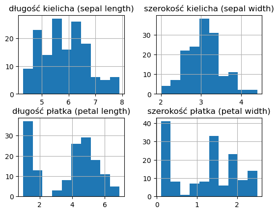

```python
df.hist() #wizualizacja za pomocą histogramu
```

```python
df = df.rename(columns={'długość kielicha (sepal length)': 'kielich_długość', 'szerokość kielicha (sepal width)' : 'kielich_szerokość', 'długość płatka (petal length)' : 'płatek_długość', 'szerokość płatka (petal width)' : 'płatek_szerokość', 'klasa (class)' : 'klasa'})
df # zmiana nazw kolumn
```

|  | kielich_długość | kielich_szerokość | płatek_długość | płatek_szerokość | klasa |
| --- | --- | --- | --- | --- | --- |
| 0 | 5.1 | 3.5 | 1.4 | 0.2 | Iris-setosa |
| 1 | 4.9 | 3.0 | 1.4 | 0.2 | Iris-setosa |
| 2 | 4.7 | 3.2 | 1.3 | 0.2 | Iris-setosa |
| 3 | 4.6 | 3.1 | 1.5 | 0.2 | Iris-setosa |
| 4 | 5.0 | 3.6 | 1.4 | 0.2 | Iris-setosa |
| ... | ... | ... | ... | ... | ... |
| 145 | 6.7 | 3.0 | 5.2 | 2.3 | Iris-virginica |
| 146 | 6.3 | 2.5 | 5.0 | 1.9 | Iris-virginica |
| 147 | 6.5 | 3.0 | 5.2 | 2.0 | Iris-virginica |
| 148 | 6.2 | 3.4 | 5.4 | 2.3 | Iris-virginica |
| 149 | 5.9 | 3.0 | 5.1 | 1.8 | Iris-virginica |

150 rows × 5 columns

```python
df['pole_kielicha']= df['kielich_długość'] * df['kielich_szerokość'] #obliczmy pole kielicha
df
```

|  | kielich_długość | kielich_szerokość | płatek_długość | płatek_szerokość | klasa | pole_kielicha |
| --- | --- | --- | --- | --- | --- | --- |
| 0 | 5.1 | 3.5 | 1.4 | 0.2 | Iris-setosa | 17.85 |
| 1 | 4.9 | 3.0 | 1.4 | 0.2 | Iris-setosa | 14.70 |
| 2 | 4.7 | 3.2 | 1.3 | 0.2 | Iris-setosa | 15.04 |
| 3 | 4.6 | 3.1 | 1.5 | 0.2 | Iris-setosa | 14.26 |
| 4 | 5.0 | 3.6 | 1.4 | 0.2 | Iris-setosa | 18.00 |
| ... | ... | ... | ... | ... | ... | ... |
| 145 | 6.7 | 3.0 | 5.2 | 2.3 | Iris-virginica | 20.10 |
| 146 | 6.3 | 2.5 | 5.0 | 1.9 | Iris-virginica | 15.75 |
| 147 | 6.5 | 3.0 | 5.2 | 2.0 | Iris-virginica | 19.50 |
| 148 | 6.2 | 3.4 | 5.4 | 2.3 | Iris-virginica | 21.08 |
| 149 | 5.9 | 3.0 | 5.1 | 1.8 | Iris-virginica | 17.70 |

150 rows × 6 columns

```python
df['pole_płatka']= df['płatek_długość'] * df['płatek_szerokość'] #obliczmy pole płatka dla wszystkich rekordów
df
```

|  | kielich_długość | kielich_szerokość | płatek_długość | płatek_szerokość | klasa | pole_kielicha | pole_płatka |
| --- | --- | --- | --- | --- | --- | --- | --- |
| 0 | 5.1 | 3.5 | 1.4 | 0.2 | Iris-setosa | 17.85 | 0.28 |
| 1 | 4.9 | 3.0 | 1.4 | 0.2 | Iris-setosa | 14.70 | 0.28 |
| 2 | 4.7 | 3.2 | 1.3 | 0.2 | Iris-setosa | 15.04 | 0.26 |
| 3 | 4.6 | 3.1 | 1.5 | 0.2 | Iris-setosa | 14.26 | 0.30 |
| 4 | 5.0 | 3.6 | 1.4 | 0.2 | Iris-setosa | 18.00 | 0.28 |
| ... | ... | ... | ... | ... | ... | ... | ... |
| 145 | 6.7 | 3.0 | 5.2 | 2.3 | Iris-virginica | 20.10 | 11.96 |
| 146 | 6.3 | 2.5 | 5.0 | 1.9 | Iris-virginica | 15.75 | 9.50 |
| 147 | 6.5 | 3.0 | 5.2 | 2.0 | Iris-virginica | 19.50 | 10.40 |
| 148 | 6.2 | 3.4 | 5.4 | 2.3 | Iris-virginica | 21.08 | 12.42 |
| 149 | 5.9 | 3.0 | 5.1 | 1.8 | Iris-virginica | 17.70 | 9.18 |

150 rows × 7 columns

```python
statystyki_kielich=df.groupby('klasa', as_index=False).agg({
    'kielich_długość':['mean', 'median',  'min', 'max'],
    'kielich_szerokość':['mean', 'median',  'min', 'max'],
    'pole_kielicha' : ['mean', 'median',  'min', 'max']
}).copy()
# obliczamy wartość średniej, mediana, miminum, maximum dla długości i szerokości kielicha dla poszczególnych klas irisa

statystyki_kielich
```

|  | klasa | kielich_długość mean | kielich_długość median | kielich_długość min | kielich_długość max | kielich_szerokość mean | kielich_szerokość median | kielich_szerokość min | kielich_szerokość max | pole_kielicha mean | pole_kielicha median | pole_kielicha min | pole_kielicha max |
| --- | --- | --- | --- | --- | --- | --- | --- | --- | --- | --- | --- | --- | --- |
| 0 | Iris-setosa | 5.006 | 5.0 | 4.3 | 5.8 | 3.418 | 3.4 | 2.3 | 4.4 | 17.2088 | 17.000 | 10.35 | 25.08 |
| 1 | Iris-versicolor | 5.936 | 5.9 | 4.9 | 7.0 | 2.770 | 2.8 | 2.0 | 3.4 | 16.5262 | 16.385 | 10.00 | 22.40 |
| 2 | Iris-virginica | 6.588 | 6.5 | 4.9 | 7.9 | 2.974 | 3.0 | 2.2 | 3.8 | 19.6846 | 20.060 | 12.25 | 30.02 |

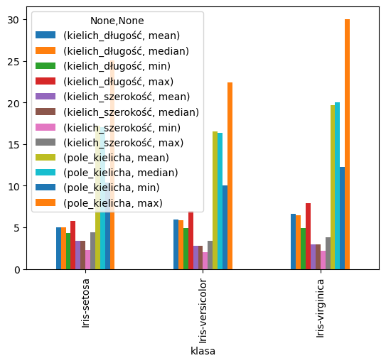

```python
statystyki_kielich.plot(kind='bar', x='klasa', y=['kielich_długość','kielich_szerokość', 'pole_kielicha',])
```

```python
statystyki_płatek=df.groupby('klasa', as_index=False).agg({
    'płatek_długość':['mean', 'median',  'min', 'max'],
    'płatek_szerokość':['mean', 'median',  'min', 'max'],
    'pole_płatka' : ['mean', 'median',  'min', 'max']
}).copy()
# obliczamy wartość średniej, mediana, miminum, maximum dla długości i szerokości płatka dla poszczególnych klas irisa

statystyki_płatek
```

|  | klasa | płatek_długość mean | płatek_długość median | płatek_długość min | płatek_długość max | płatek_szerokość mean | płatek_szerokość median | płatek_szerokość min | płatek_szerokość max | pole_płatka mean | pole_płatka median | pole_płatka min | pole_płatka max |
| --- | --- | --- | --- | --- | --- | --- | --- | --- | --- | --- | --- | --- | --- |
| 0 | Iris-setosa | 1.464 | 1.50 | 1.0 | 1.9 | 0.244 | 0.2 | 0.1 | 0.6 | 0.3628 | 0.300 | 0.11 | 0.96 |
| 1 | Iris-versicolor | 4.260 | 4.35 | 3.0 | 5.1 | 1.326 | 1.3 | 1.0 | 1.8 | 5.7204 | 5.615 | 3.30 | 8.64 |
| 2 | Iris-virginica | 5.552 | 5.55 | 4.5 | 6.9 | 2.026 | 2.0 | 1.4 | 2.5 | 11.2962 | 11.445 | 7.50 | 15.87 |

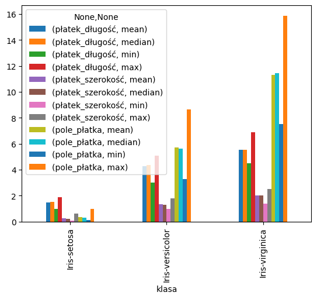

```python
statystyki_płatek.plot(kind='bar', x='klasa')
```

# Analiza relacji między zmiennymi.

```python
df.corr() # przedstawiamy macierz korlelacji pomiedzy poszczególnymi kolumnami
```

|  | kielich_długość | kielich_szerokość | płatek_długość | płatek_szerokość | pole_kielicha | pole_płatka |
| --- | --- | --- | --- | --- | --- | --- |
| kielich_długość | 1.000000 | -0.109369 | 0.871754 | 0.817954 | 0.683362 | 0.857326 |
| kielich_szerokość | -0.109369 | 1.000000 | -0.420516 | -0.356544 | 0.645421 | -0.280612 |
| płatek_długość | 0.871754 | -0.420516 | 1.000000 | 0.962757 | 0.366584 | 0.958472 |
| płatek_szerokość | 0.817954 | -0.356544 | 0.962757 | 1.000000 | 0.375365 | 0.980229 |
| pole_kielicha | 0.683362 | 0.645421 | 0.366584 | 0.375365 | 1.000000 | 0.459484 |
| pole_płatka | 0.857326 | -0.280612 | 0.958472 | 0.980229 | 0.459484 | 1.000000 |

# Analiza wartości odstajacych.

```
klasa
Iris-setosa        Axes(0.125,0.11;0.775x0.77)
Iris-versicolor    Axes(0.125,0.11;0.775x0.77)
Iris-virginica     Axes(0.125,0.11;0.775x0.77)
dtype: object
```

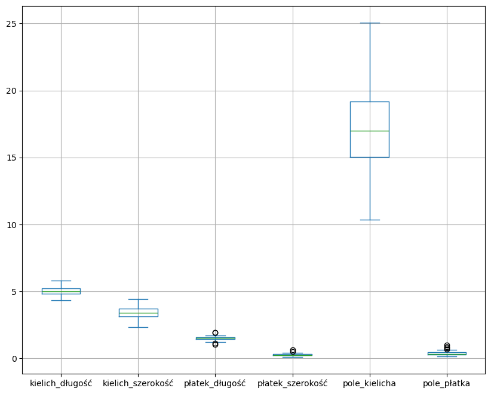

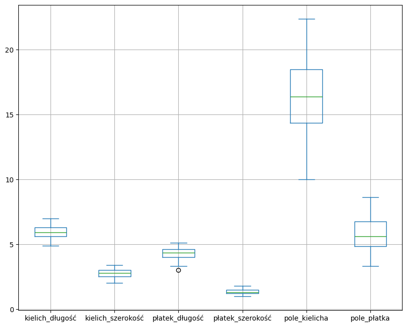

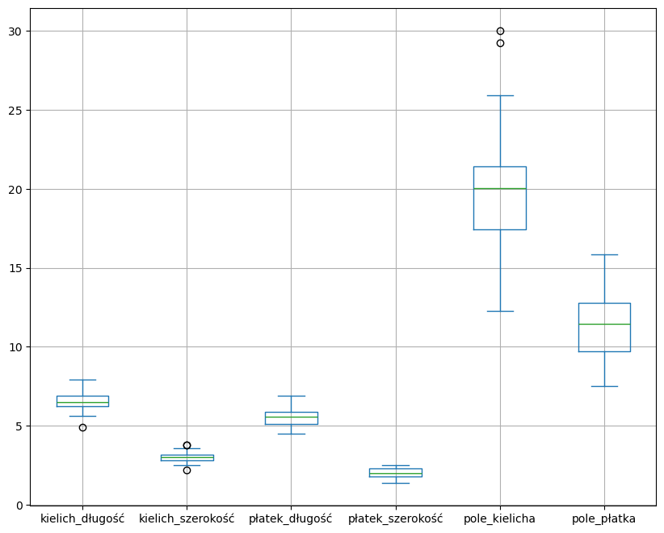

```python
df.groupby('klasa').plot(kind='box', figsize=(10,8), grid=True) #przedstawienie wartości odstajacych za pomocą wykresów pudełkowych, figsize - rozmiar, grid- linie siatki
```

# Wartości odstające.

##### W analizie danych Iris-setosa wartości odstające pojawiają się w długości i szerokości płatków.

##### Natomista analiza klasy Iris-versicolor wykazała wartości odstające jedynie w długości płatków.

##### W przypadu klasy Iris-virginica wartości odstając występują w długości i szerokości kieicha. w

# Wnioski końcowe.

##### Najwyższa wartość zarówno w średniej szerokości jak i długości płatka występuje u Iris-virginica.

##### Analizowane klasy Irysów można odróżnić od siebie na podstawi wielkości płatka oraz kielicha.

[figure not shown]